# Multiple Linear Regression

## 1.5 Prediction

```r
data2.pred.res <- augment(prelim.final.m)
data2.pred.res
```

```
# A tibble: 299 × 12
   literacy_score duration_of_employment family_members_spouse
            <dbl>                  <dbl> <fct>
 1            102                     10 No
 2            105                      9 No
 3            102                      9 Yes
 4            107                      9 No
 5            111                     10 No
 6             98                      8 No
 7             97                     10 No
 8             98                     23 No
 9            108                      9 No
10             84                      9 No
# ℹ 289 more rows
# ℹ 9 more variables: current_hospital_posting <fct>, peers_friends <fct>,
#   previous_experience_of_being_bullied <fct>, .fitted <dbl>, .resid <dbl>,
#   .hat <dbl>, .sigma <dbl>, .cooksd <dbl>, .std.resid <dbl>
```

## 1.6 Check for influential

#Testing for Influential Observations Keep standardized residuals between 2 and -2 (values above 2 or lower than −2 considered as influential observations)

```r
non.influen.obs <-
  data2.pred.res %>%
  filter(.std.resid < 2 & .std.resid > -2 )
```

Re-run the Model with the non-influential observations (final model)

```r
prelim.final.m2 <- lm (literacy_score~ duration_of_employment + family_members_spouse + current_hospital_posting + previous_experience_of_being_bullied + peers_friends, data = non.influen.obs)
summary ( prelim.final.m2)
```

```
Call:
lm(formula = literacy_score ~ duration_of_employment + family_members_spouse +
    current_hospital_posting + previous_experience_of_being_bullied +
    peers_friends, data = non.influen.obs)

Residuals:
     Min       1Q   Median       3Q      Max
-14.5639  -4.6679  -0.0265   4.3125  15.1355

Coefficients:
                                        Estimate Std. Error t value Pr(>|t|)
(Intercept)                             98.64511    1.20382  81.943   <2e-16
duration_of_employment                  -0.07618    0.06512  -1.170   0.2431
family_members_spouseYes                 1.88305    1.27971   1.471   0.1423
current_hospital_postingHSIP             2.08555    1.11908   1.864   0.0634
current_hospital_postingHTM             -0.06297    1.28411  -0.049   0.9609
current_hospital_postingHUSM            -0.09498    0.91836  -0.103   0.9177
previous_experience_of_being_bulliedYes  1.83272    0.84150   2.178   0.0303
peers_friendsYes                         1.21412    0.86686   1.401   0.1624

(Intercept)                             ***
duration_of_employment
family_members_spouseYes
current_hospital_postingHSIP            .
current_hospital_postingHTM
current_hospital_postingHUSM
previous_experience_of_being_bulliedYes *
peers_friendsYes
---
Signif. codes:  0 '***' 0.001 '**' 0.01 '*' 0.05 '.' 0.1 ' ' 1

Residual standard error: 6.402 on 279 degrees of freedom
Multiple R-squared:  0.06422,   Adjusted R-squared:  0.04074
F-statistic: 2.735 on 7 and 279 DF,  p-value: 0.009244
```

#Model Assumptions for final model 1.Run Diagnostic Plots

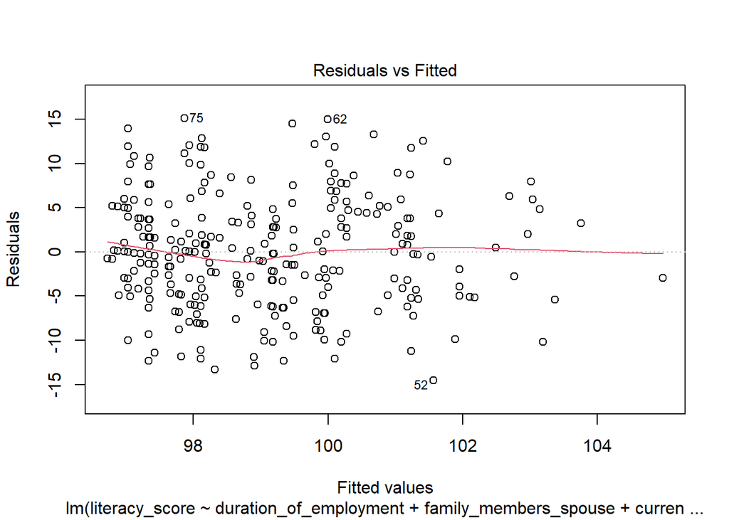

```r
plot(prelim.final.m2, which = 1)
```

Comment

The red line through the scatter plot straight, horizontal and not curved indicating linearity assumption is satisfied. The homoscedasticity assumption is met as the residuals are equally spread around the y = 0 line

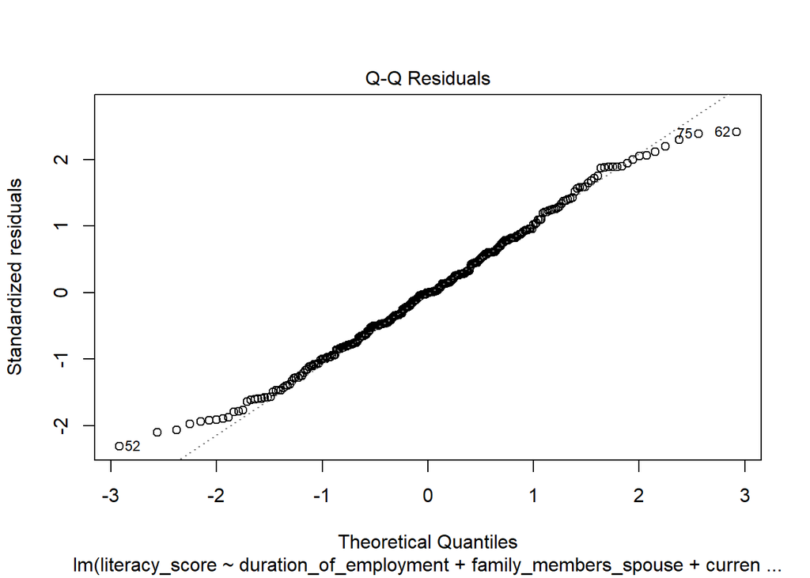

```r
plot(prelim.final.m2, which = 2)
```

Comment

In Q-Q plot, No obvious data point has large residuals, almost all observation lie well along the 45 degree line indicating normality holds

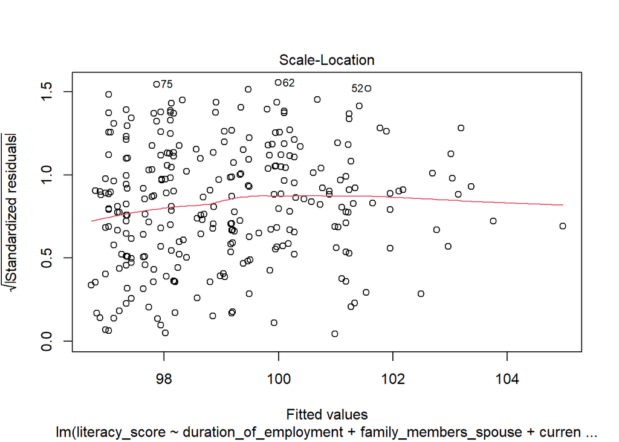

```r
plot(prelim.final.m2, which = 3)
```

Comment